# TFM2_Taraspina_miTags_analysis

lrubinat

5/23/2017

```r
library(data.table)
library(dplyr)
library(DT)
library(ggplot2)
library(gtools)
library(vegan)
library(iNEXT)
library(fossil)
```

# 1) 18S amplicons

## 1.1) Data overview

Let’s read the dataset and remove the samples containing less than 1154 reads:

```
## [1] 8642   58
```

```
##   OTU_no TARA_100_SUR_0d2_3 TARA_102_SUR_0d2_3 TARA_109_SUR_0d2_3
## 1  OTU_1                  0                  0                  0
## 2  OTU_2                  0                  0                  0
## 3  OTU_3                  0                  0                  0
## 4  OTU_4                  0                  0                  0
## 5  OTU_5                  0                  0                  0
##   TARA_110_SUR_0d2_3
## 1                  0
## 2                  0
## 3                  0
## 4                  0
## 5                  0
```

```
## [1] 8642   57
```

```
##       TARA_100_SUR_0d2_3 TARA_102_SUR_0d2_3 TARA_109_SUR_0d2_3
## OTU_1                  0                  0                  0
## OTU_2                  0                  0                  0
## OTU_3                  0                  0                  0
## OTU_4                  0                  0                  0
## OTU_5                  0                  0                  0
##       TARA_110_SUR_0d2_3 TARA_111_SUR_0d2_3
## OTU_1                  0                  0
## OTU_2                  0                  0
## OTU_3                  0                  1
## OTU_4                  0                  0
## OTU_5                  0                  0
```

```
## [1] 8642    2
```

```
##                                                                                                                                              OTUId
## OTU_1                            SILVA.v123_KJ760253.1.1809_Eukaryota;SAR;Rhizaria;Retaria;Polycystinea;Spumellaria;Actinomma;uncultured_eukaryote
## OTU_2                            SILVA.v123_AF018162.1.1798_Eukaryota;SAR;Rhizaria;Retaria;Polycystinea;Collodaria;Collozoum;Collozoum_serpentinum
## OTU_3         SILVA.v123_KJ759918.1.2019_Eukaryota;Excavata;Discoba;Discicristata;Euglenozoa;Diplonemea;SCM38C39_marine_group;uncultured_eukaryote
## OTU_4 SILVA.v123_FN598252.1.1343_Eukaryota;Excavata;Discoba;Discicristata;Euglenozoa;Diplonemea;SCM38C39_marine_group;uncultured_marine_diplonemid
## OTU_5                       SILVA.v123_KJ760105.1.1803_Eukaryota;SAR;Alveolata;Protalveolata;Syndiniales;Syndiniales_Group_II;uncultured_eukaryote
##       classif
## OTU_1    <NA>
## OTU_2    <NA>
## OTU_3    <NA>
## OTU_4    <NA>
## OTU_5    <NA>
```

```
## [1] 8642   55
```

```
##       TARA_100_SUR_0d2_3 TARA_102_SUR_0d2_3 TARA_109_SUR_0d2_3
## OTU_1                  0                  0                  0
## OTU_2                  0                  0                  0
## OTU_3                  0                  0                  0
## OTU_4                  0                  0                  0
## OTU_5                  0                  0                  0
##       TARA_110_SUR_0d2_3 TARA_111_SUR_0d2_3
## OTU_1                  0                  0
## OTU_2                  0                  0
## OTU_3                  0                  1
## OTU_4                  0                  0
## OTU_5                  0                  0
```

```
##    Min. 1st Qu.  Median    Mean 3rd Qu.    Max.
##      93    1840    3086    4440    5808   23780
```

```
## TARA_100_SUR_0d2_3 TARA_141_SUR_0d2_3  TARA_93_SUR_0d2_3
##                949                881                 93
##  TARA_94_SUR_0d2_3             MP0528             MP0778
##                638                176                805
##             MP1176             MP1421             MP1857
##                663                941                498
##             MP2243
##                509
```

```
## [1] 8642   45
```

```
## [1] 8642   43
```

```
## [1] 8642    0
```

Table dimensions and content outline:

```
## [1] 8642   43
```

```
##       TARA_102_SUR_0d2_3 TARA_109_SUR_0d2_3 TARA_110_SUR_0d2_3
## OTU_1                  0                  0                  0
## OTU_2                  0                  0                  0
## OTU_3                  0                  0                  0
## OTU_4                  0                  0                  0
## OTU_5                  0                  0                  0
##       TARA_111_SUR_0d2_3 TARA_112_SUR_0d2_3
## OTU_1                  0                  0
## OTU_2                  0                  0
## OTU_3                  1                  0
## OTU_4                  0                  0
## OTU_5                  0                  0
```

Minimum number of reads per station:

```r
min(colSums(tb18_tax_occur_min1154))
```

```
## [1] 1154
```

Maximum number of reads per station:

```r
max(colSums(tb18_tax_occur_min1154))
```

```
## [1] 23781
```

Identification of stations with higher number of reads:

```r
amplicons_per_sample<-colSums(tb18_tax_occur_min1154)
amplicons_per_sample[which(colSums(tb18_tax_occur_min1154)>20000)]
```

```
## TARA_84_SUR_0d2_3
##             23781
```

Overall reads per sample:

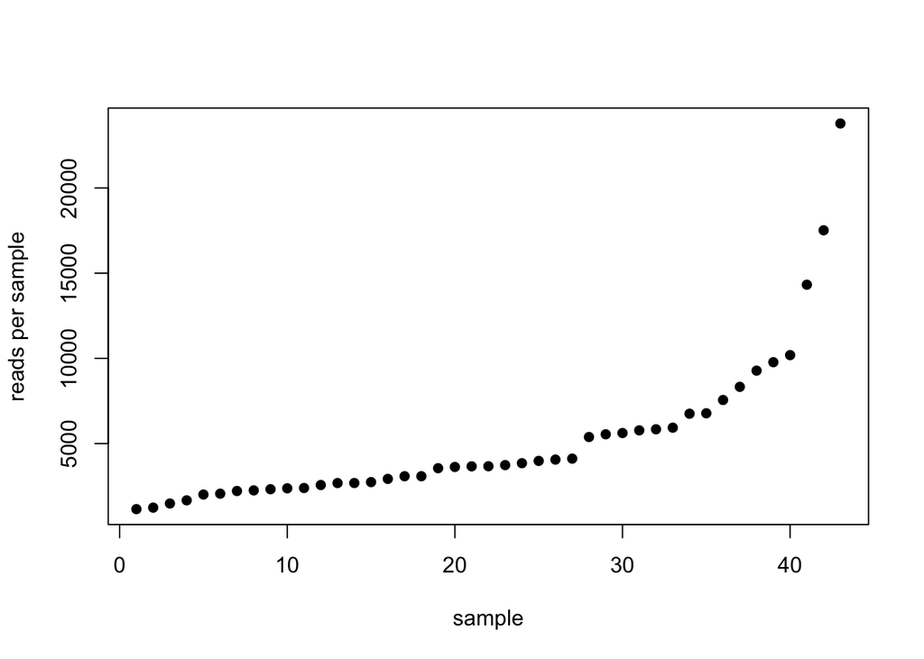

## 1.2) Normalization

Let’s normalize the original dataset by randomly subsampling 1154 reads in each station:

```r
tb18_tax_occur_min1154_t<-t(tb18_tax_occur_min1154)
tb18_tax_occur_ss1154<-rrarefy(tb18_tax_occur_min1154_t, 1154)
```

The normalized table shows the following dimensions and format:

```
## [1]   43 8642
```

```
##                    OTU_1 OTU_2 OTU_3 OTU_4 OTU_5
## TARA_102_SUR_0d2_3     0     0     0     0     0
## TARA_109_SUR_0d2_3     0     0     0     0     0
## TARA_110_SUR_0d2_3     0     0     0     0     0
## TARA_111_SUR_0d2_3     0     0     1     0     0
## TARA_112_SUR_0d2_3     0     0     0     0     0
```

Its content fits with the expected normalization values (1154 reads per station):

```r
rowSums(tb18_tax_occur_ss1154)
```

```
## TARA_102_SUR_0d2_3 TARA_109_SUR_0d2_3 TARA_110_SUR_0d2_3
##               1154               1154               1154
## TARA_111_SUR_0d2_3 TARA_112_SUR_0d2_3 TARA_122_SUR_0d2_3
##               1154               1154               1154
## TARA_123_SUR_0d2_3 TARA_124_SUR_0d2_3 TARA_125_SUR_0d2_3
##               1154               1154               1154
## TARA_128_SUR_0d2_3 TARA_132_SUR_0d2_3 TARA_133_SUR_0d2_3
##               1154               1154               1154
## TARA_137_SUR_0d2_3 TARA_138_SUR_0d2_3 TARA_140_SUR_0d2_3
##               1154               1154               1154
## TARA_142_SUR_0d2_3 TARA_145_SUR_0d2_3 TARA_146_SUR_0d2_3
##               1154               1154               1154
## TARA_148_SUR_0d2_3 TARA_149_SUR_0d2_3 TARA_150_SUR_0d2_3
##               1154               1154               1154
## TARA_151_SUR_0d2_3 TARA_152_SUR_0d2_3  TARA_56_SUR_0d2_3
##               1154               1154               1154
##  TARA_57_SUR_0d2_3  TARA_62_SUR_0d2_3  TARA_64_SUR_0d2_3
##               1154               1154               1154
##  TARA_65_SUR_0d2_3  TARA_66_SUR_0d2_3  TARA_68_SUR_0d2_3
##               1154               1154               1154
##  TARA_72_SUR_0d2_3  TARA_76_SUR_0d2_3  TARA_78_SUR_0d2_3
##               1154               1154               1154
##  TARA_82_SUR_0d2_3  TARA_84_SUR_0d2_3  TARA_85_SUR_0d2_3
##               1154               1154               1154
##  TARA_96_SUR_0d2_3  TARA_98_SUR_0d2_3  TARA_99_SUR_0d2_3
##               1154               1154               1154
##             MP0311             MP1517             MP1672
##               1154               1154               1154
##             MP2821
##               1154
```

Let’s check out how many OTUs don’t appear in the new table:

```r
length(which(colSums(tb18_tax_occur_ss1154)==0)) #2923
```

```
## [1] 2914
```

```r
tb18_tax_occur_ss1154_no_cero<-tb18_tax_occur_ss1154[,-(which(colSums(tb18_tax_occur_ss1154)==0))]
tb18_tax_occur_ss1154_no_cero<-tb18_tax_occur_ss1154_no_cero[mixedorder(row.names(tb18_tax_occur_ss1154_no_cero)),]
dim(tb18_tax_occur_ss1154_no_cero) #43 5719
```

```
## [1]   43 5728
```

Datasets summary:

```r
dim(tb18_tax) #8642   57
```

```
## [1] 8642   57
```

```r
dim(tb18_tax_occur) #8642   55
```

```
## [1] 8642   55
```

```r
dim(tb18_tax_occur_ss1154_no_cero) #43 5719
```

```
## [1]   43 5728
```

## 1.3) General community analysis

### 1.3.1) Richness and evenness (Shannon index)

Most of the samples take Shannon Index values around 6:

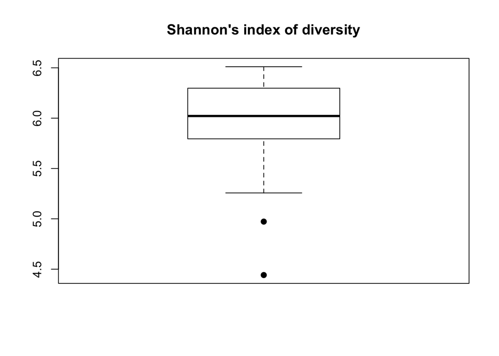

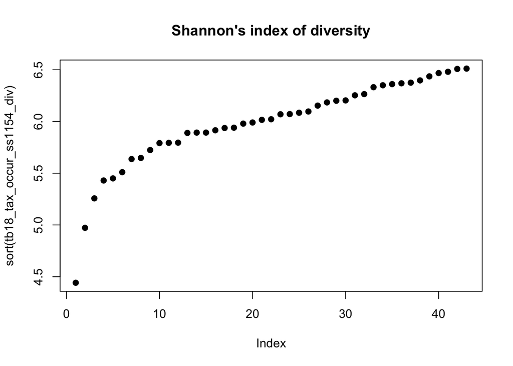

### 1.3.2) Richness: OTU number

Lowest number of OTUs per sample:

```
## [1] 356
```

Maximum number of OTUs per sample:

```
## [1] 800
```

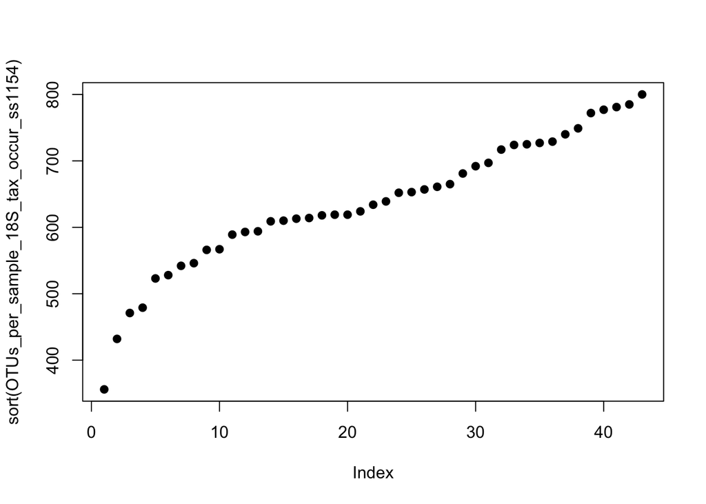

```r
plot(sort(OTUs_per_sample_18S_tax_occur_ss1154), pch=19)
```

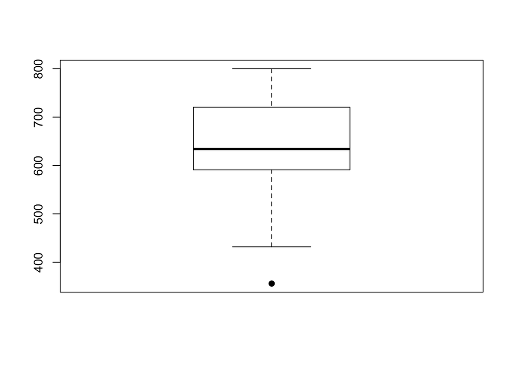

```r
boxplot(OTUs_per_sample_18S_tax_occur_ss1154, pch=19)
```

### 1.3.3) Index of evenness

#### 1.3.3.1) Pielou’s index

```r
pielou_evenness_18S_tax_occur_ss1154<-tb18_tax_occur_ss1154_div/log(OTUs_per_sample_18S_tax_occur_ss1154)
```

The Pielou index (constrained between 0 and 1) takes values closer to 1 as the variation of species proportion in a sample increases. Most of the samples get values around 0.95, meaning that the numerical composition of different OTUs in a sample is highly variable - there’s no constant presence of dominant species.

The less variation in communities between the species (and the presence of a dominant specie), the lower J’ is.

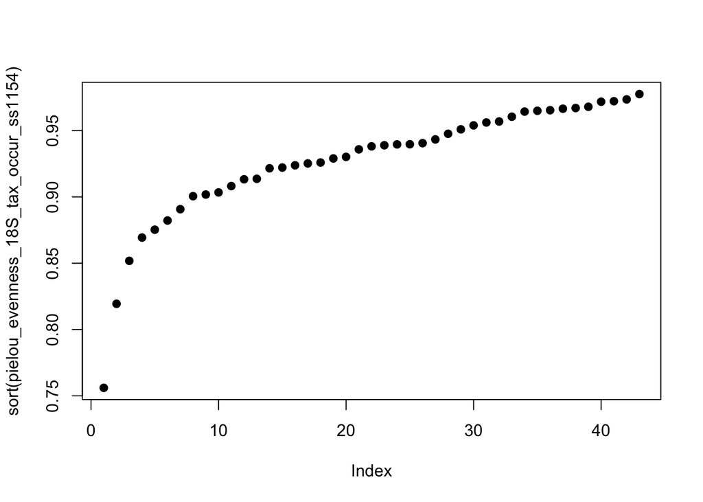

```r
plot(sort(pielou_evenness_18S_tax_occur_ss1154), pch=19)
```

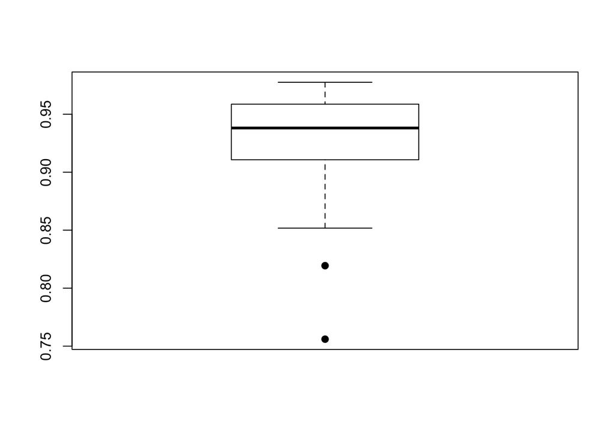

```r
boxplot(pielou_evenness_18S_tax_occur_ss1154, pch=19)
```

```r
head(sort(colSums(tb18_tax_occur_ss1154_no_cero), decreasing=T), n=10L)
```

```
##   OTU_38 OTU_3677  OTU_751 OTU_5415 OTU_3374 OTU_2494 OTU_2631 OTU_3177
##      868      689      545      534      438      344      303      282
## OTU_1032 OTU_3569
##      263      256
```

Most of the OTUs show very few occurrences; suggesting that we will probably be able to identify a significant ammount of rare otus:

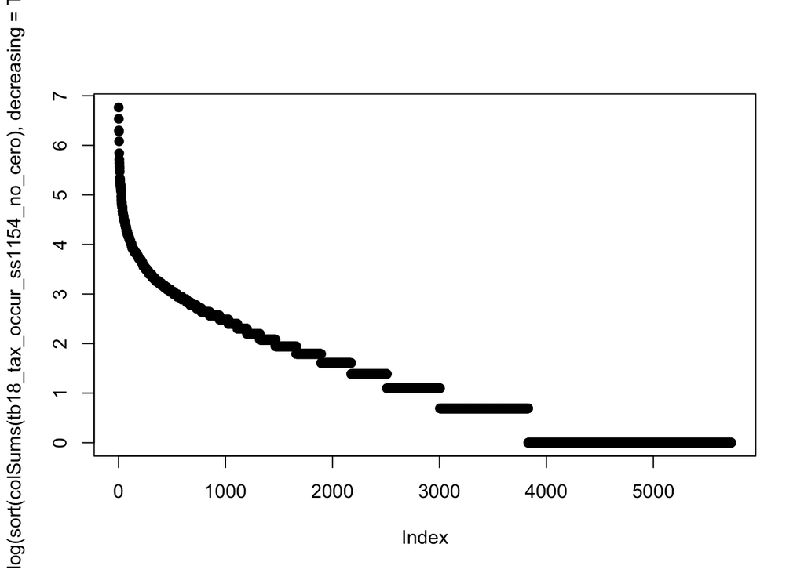

```r
plot(log(sort(colSums(tb18_tax_occur_ss1154_no_cero), decreasing=T)), pch=19)
```

### 1.3.4) Abundance Models

#### 1.3.4.1) Rank-Abundance or Dominance/Diversity Model (“radfit”)

The OTUs abundance distribution fits relativelly close to log-normal model.

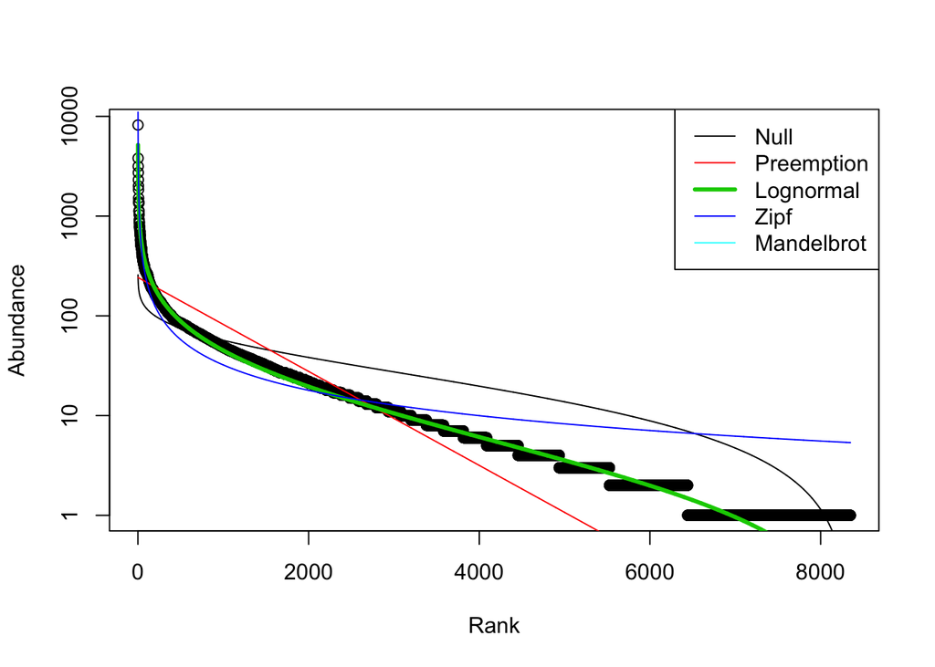

#### 1.3.4.2) Preston’s Lognormal Model

According to Preston’s lognormal model fit into species frequencies groups, we’re missing 1588.816 species:

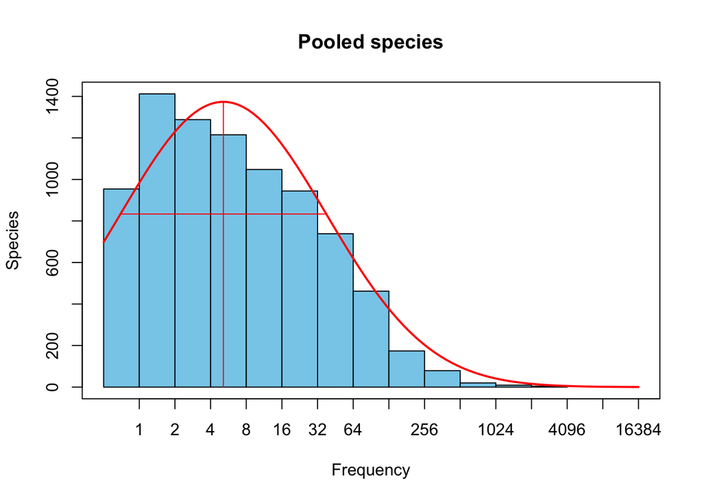

```r
tb18_tax_occur_ss1154_prestonfit<-prestonfit(colSums(tb18_tax_occur_min1154_t))
plot(tb18_tax_occur_ss1154_prestonfit, main="Pooled species")
```

```r
veiledspec(tb18_tax_occur_ss1154_prestonfit)
```

```
## Extrapolated     Observed       Veiled
##     9937.816     8349.000     1588.816
```

When computing Prestons’ lognormal model fit without pooling data into groups, we seem to miss 1385.371 species:

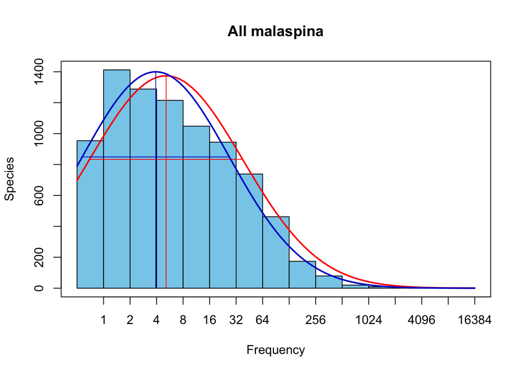

```
## Extrapolated     Observed       Veiled
##     9734.371     8349.000     1385.371
```

### 1.3.5) Rarefaction curves of rarefied and non-rarefied datasets

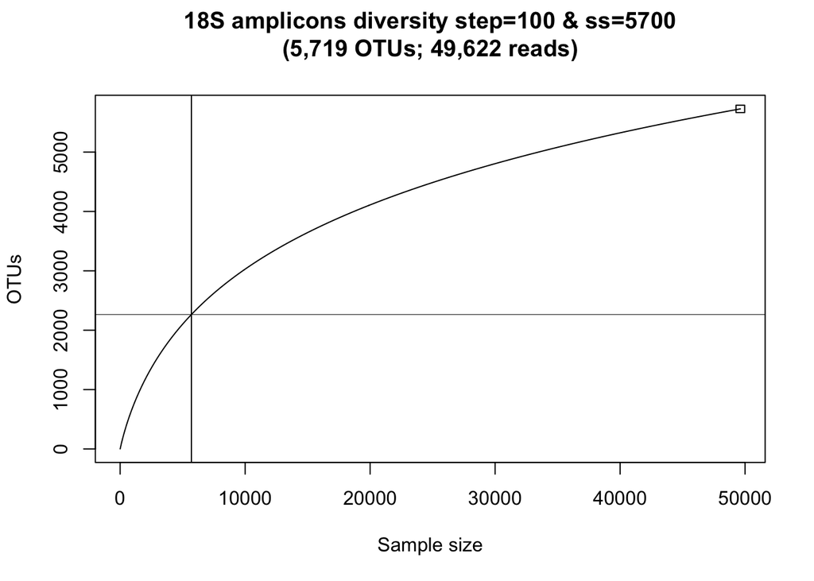

```r
rarec_input<-t(as.matrix(colSums(tb18_tax_occur_ss1154_no_cero)))

#tb18_rarecurve_step1000_10000<-rarecurve(rarec_input, step = 1000, 10000, xlab = "Sample size", ylab = "OTUs", label = TRUE, main="18S amplicons diversity step=1000 & ss=10000\n(40,816 OTUs; 5,247,375 reads)\n")
#tb18_rarecurve_step1000_10000

tb18_rarecurve_step100_5700<-rarecurve(rarec_input, step = 100, 5700, xlab = "Sample size", ylab = "OTUs", label = TRUE, main="18S amplicons diversity step=100 & ss=5700\n(5,719 OTUs; 49,622 reads)\n")
```

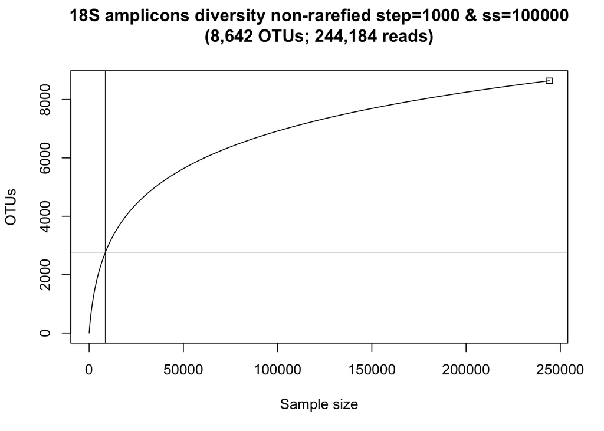

```r
#without rarefying
rarec_allOTUs_input<-t(as.matrix(colSums(t(tb18_tax_occur))))
tb18_rarecurve_allOTUs_step100_8642<-rarecurve(rarec_allOTUs_input, step = 100, 8642, xlab = "Sample size", ylab = "OTUs", label = TRUE, main="18S amplicons diversity non-rarefied step=1000 & ss=100000\n(8,642 OTUs; 244,184 reads)\n")
```

### 1.3.6) Beta diversity

#### 1.3.6.1) Dissimilarity matrix using Bray-Curtis index:

The Bray-Curtis dissimilarity, constrained between 0 (minimum distance) and 1 (highest dissimilarity) allows us to quantify the differences between samples according to the composition and relative abundance of their OTUs. In our dataset, most of the samples pairs take dissimilarity values around 0.8, meaning that their composition is substantially different.

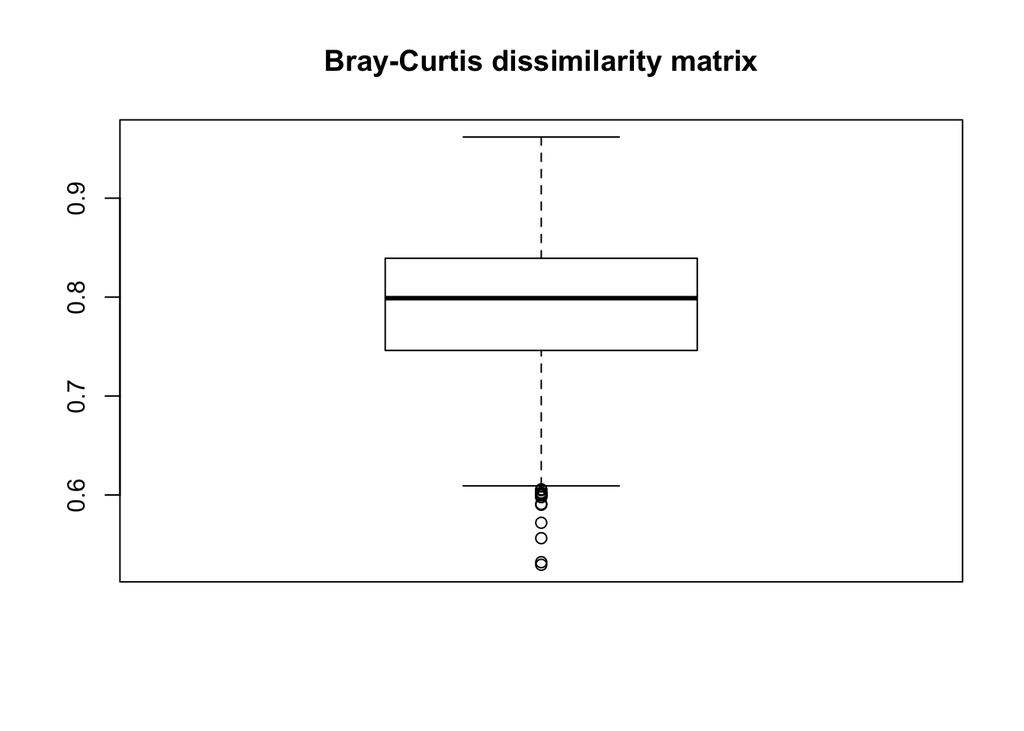

#### 1.3.6.2) Hierarchical clustering

The stations seem to form clusters according to geographic localization, but there are no evident clusters separated from the general groups, apart from the one containing TARA_84, TARA_82 and TARA_85.

(To be done: assign Longhurst provinces information to each station and check if any of the central clusters is meaningful regarding to the samples’ geographical location)

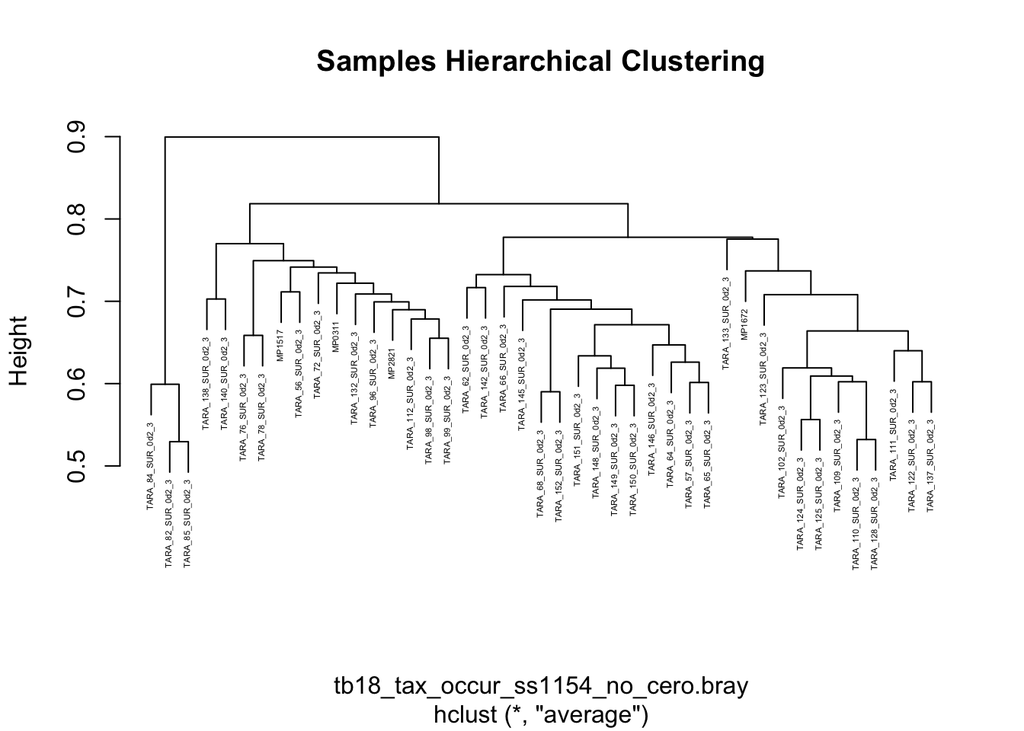

#### 1.3.6.3) Non-metric multidimensional scaling

We can identify a prominent group in the central part of the NMDS plot and a few outliers (TARA 82, 84 and 85) in the central-right edge of the plot. The stress parameter takes a value below 0.2, suggesting that the plot is acceptable.

```
##
## Call:
## monoMDS(dist = tb18_tax_occur_ss1154_no_cero.bray)
##
## Non-metric Multidimensional Scaling
##
## 43 points, dissimilarity 'bray', call 'vegdist(x = tb18_tax_occur_ss1154_no_cero, method = "bray")'
##
## Dimensions: 2
## Stress:     0.1373119
## Stress type 1, weak ties
## Scores scaled to unit root mean square, rotated to principal components
## Stopped after 81 iterations: Stress nearly unchanged (ratio > sratmax)
```

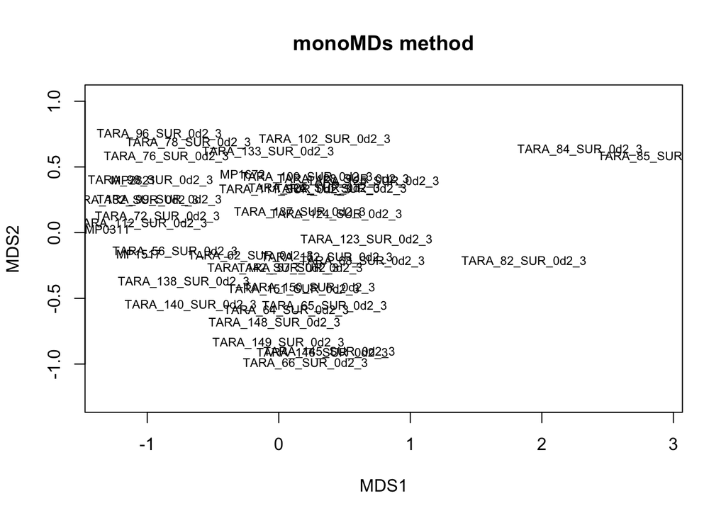

When implementing a most robut function for computing NMDS plots, the result is quiet the same:

```
## *** Solution reached
```

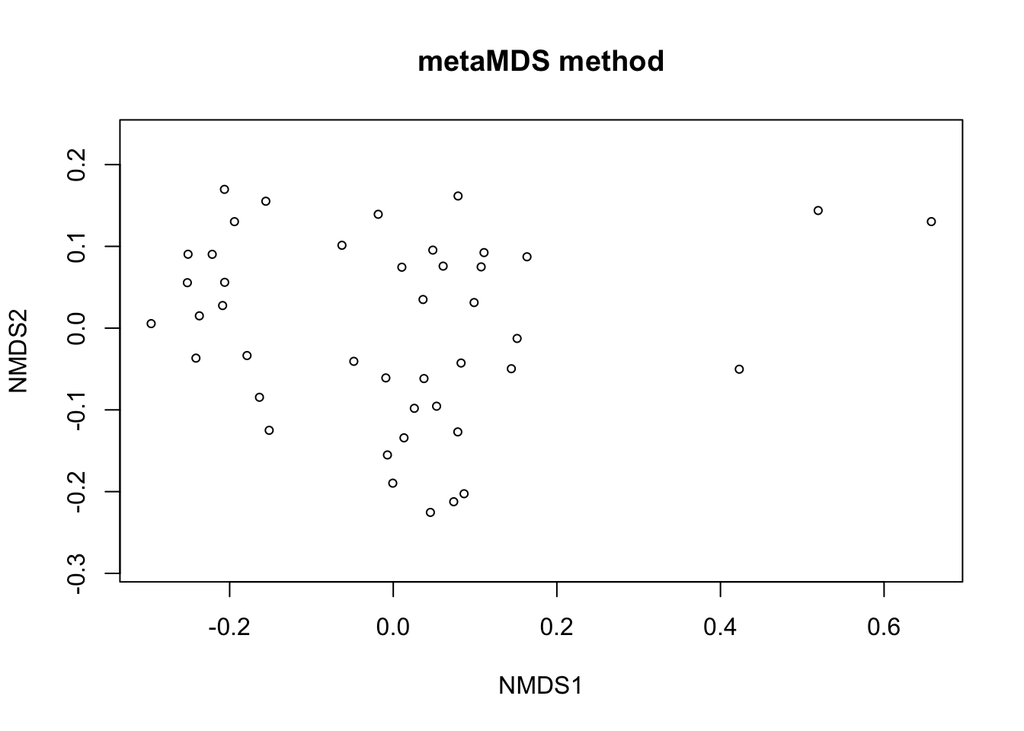

## 1.4) Geographical analysis

Working datasets:

1. Community matrix: tb18_tax_occur_ss1154_no_cero

```r
dim(tb18_tax_occur_ss1154_no_cero)
```

```
## [1]   43 5728
```

```r
tb18_tax_occur_ss1154_no_cero[1:5, 1:5]
```

```
##                    OTU_1 OTU_2 OTU_3 OTU_5 OTU_6
## MP0311                 0     0     0     0     0
## MP1517                 0     0     0     0     1
## MP1672                 0     0     0     0     0
## MP2821                 0     3     0     0     0
## TARA_102_SUR_0d2_3     0     0     0     0     0
```

2. Community Bray-Curtis: tb18_tax_occur_ss1154_no_cero.bray

```r
tb18_tax_occur_ss1154_no_cero.bray<-as.matrix(tb18_tax_occur_ss1154_no_cero.bray)
```

```
## [1] 43 43
```

3. Stations distances in km: geo_distances_MP_18S

```r
dim(geo_distances_MP_18S)
```

```
## [1] 43 43
```

Communities quickly change their composition across geographical distances:

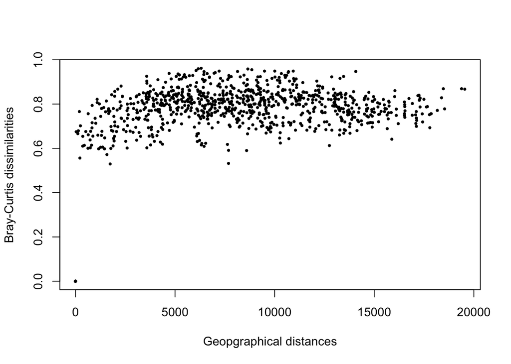

```r
plot(geo_distances_MP_18S, tb18_tax_occur_ss1154_no_cero.bray, pch=19, cex=0.4, xlab="Geopgraphical distances", ylab="Bray-Curtis dissimilarities")
```

### 1.4.1) Mantel correlograms

Mantel statistic is -significantlly- so low, meaning that the correlation between samples dissimilarity and geographical distances is weak.

```r
mantel(geo_distances_MP_18S, tb18_tax_occur_ss1154_no_cero.bray)
```

```
##
## Mantel statistic based on Pearson's product-moment correlation
##
## Call:
## mantel(xdis = geo_distances_MP_18S, ydis = tb18_tax_occur_ss1154_no_cero.bray)
##
## Mantel statistic r: 0.1186
##       Significance: 0.018
##
## Upper quantiles of permutations (null model):
##    90%    95%  97.5%    99%
## 0.0646 0.0894 0.1075 0.1334
## Permutation: free
## Number of permutations: 999
```

Maximum distance between samples:

```
## [1] 19543.94
```

Minimum distance between samples:

```
## [1] 0
```

Correlograms:

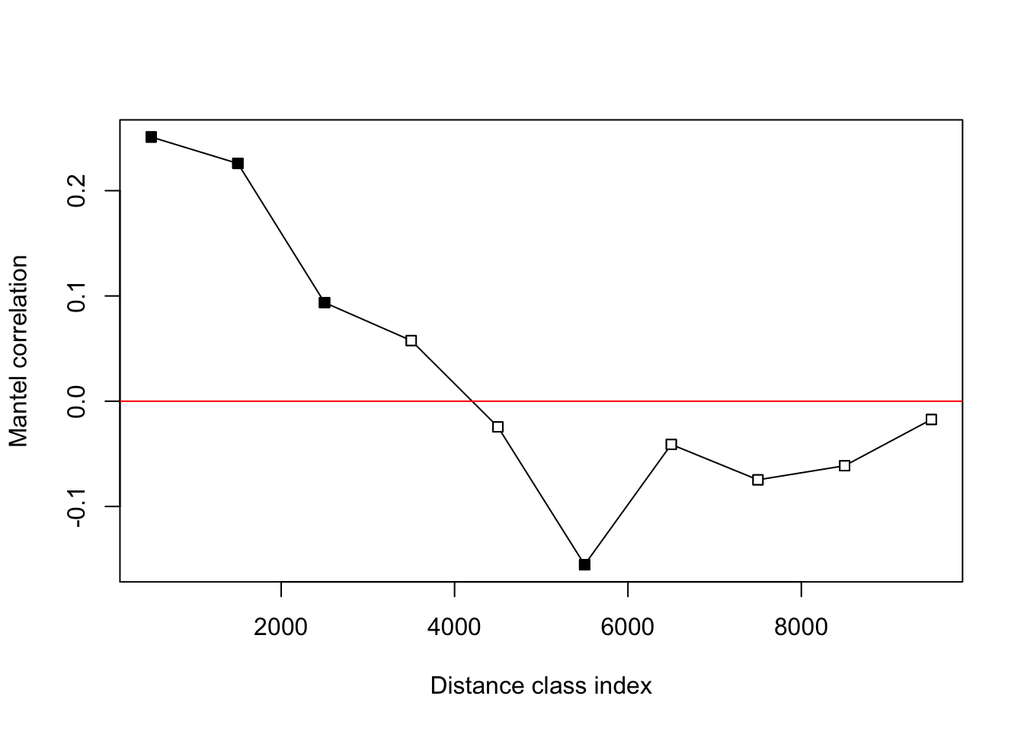

```r
MP_18s_ss1154_mantel_correl_by_1000km<-mantel.correlog(tb18_tax_occur_ss1154_no_cero.bray, D.geo=geo_distances_MP_18S, break.pts=seq(0,20000, by=1000))
plot(MP_18s_ss1154_mantel_correl_by_1000km)
```

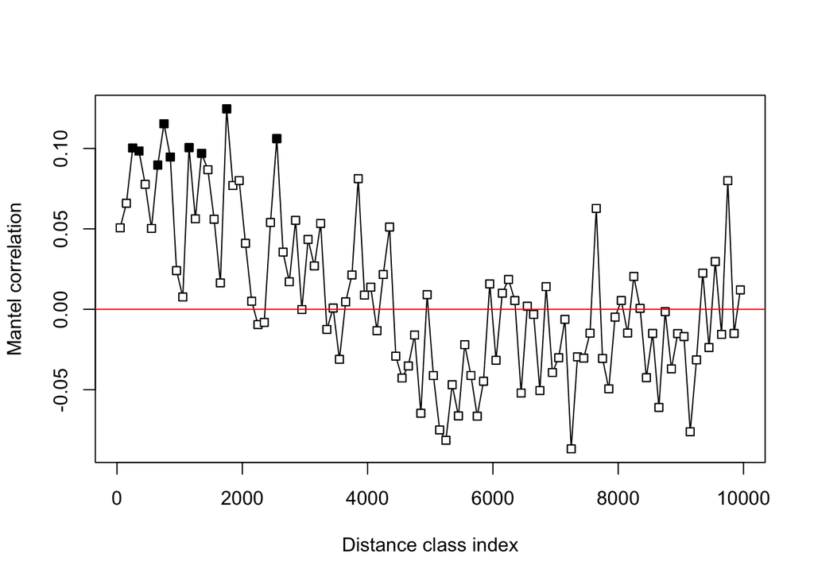

```r
MP_18s_ss1154_mantel_correl_by_100km<-mantel.correlog(tb18_tax_occur_ss1154_no_cero.bray, D.geo=geo_distances_MP_18S, break.pts=seq(0,20000, by=100))
plot(MP_18s_ss1154_mantel_correl_by_100km)
```

## 1.5) Abundance vs. occurence

In the following plot, we can appreciate the OTUs distribution according to their percentage of occurence and relative abundance. The red line keeps up OTUs that occur in more than 80% of the samples, the green line limits regionally rare OTUs (< 0.001%), and the blue one restricts regionally abundant OTUs (> 0.1%).

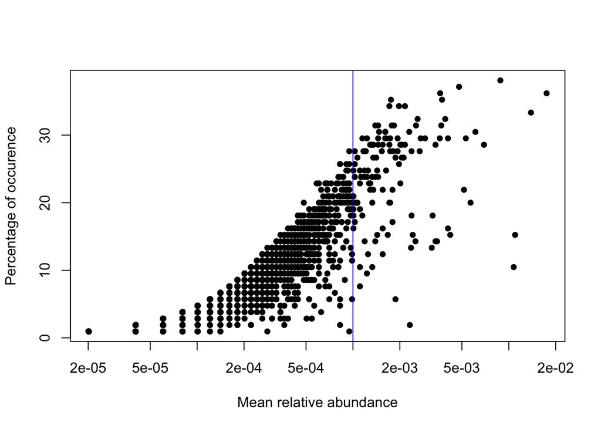

Regionally abundant OTUs (relative abundance over 0.1%):

```
##          mean_rabund perc_occur
## OTU_38   0.017492241  36.190476
## OTU_3677 0.013884970  33.333333
## OTU_751  0.010983032  15.238095
## OTU_5415 0.010761356  10.476190
## OTU_3374 0.008826730  38.095238
## OTU_2494 0.006932409  28.571429
## OTU_2631 0.006106163  30.476190
## OTU_3177 0.005682963  20.000000
## OTU_1032 0.005300069  29.523810
## OTU_3569 0.005159002  21.904762
## OTU_933  0.004796260  37.142857
## OTU_3282 0.004211842  15.238095
## OTU_2910 0.004070775  29.523810
## OTU_5120 0.004070775  16.190476
## OTU_3729 0.003909556  32.380952
## OTU_2200 0.003728185  35.238095
## OTU_1921 0.003687880  31.428571
## OTU_1383 0.003627423  36.190476
## OTU_3454 0.003607271  29.523810
## OTU_3227 0.003466205  14.285714
## OTU_1597 0.003385595  28.571429
## OTU_4176 0.003385595  14.285714
## OTU_4144 0.003244529  18.095238
## OTU_4227 0.003204224  13.333333
## OTU_1456 0.002901939  29.523810
## OTU_1833 0.002720567  29.523810
## OTU_974  0.002680263  27.619048
## OTU_4125 0.002599653  32.380952
## OTU_3038 0.002539196  31.428571
## OTU_4123 0.002519044  14.285714
## OTU_4103 0.002418282  15.238095
## OTU_2031 0.002377978  27.619048
## OTU_4518 0.002377978  18.095238
## OTU_3271 0.002357825  13.333333
## OTU_950  0.002317520   1.904762
## OTU_896  0.002297368  30.476190
## OTU_380  0.002156302  34.285714
## OTU_3871 0.002156302  28.571429
## OTU_2654 0.002115997  26.666667
```

[output cut: 84 more lines]

```
## OTU_1911 0.001068075  20.000000
## OTU_599  0.001068075  20.000000
## OTU_1901 0.001047922  20.000000
## OTU_2219 0.001027770  27.619048
## OTU_1003 0.001027770  25.714286
## OTU_1975 0.001027770  23.809524
## OTU_295  0.001027770  23.809524
## OTU_2906 0.001027770  20.000000
## OTU_4110 0.001027770  17.142857
## OTU_373  0.001007618  20.952381
## OTU_1276 0.001007618  20.000000
## OTU_2466 0.001007618  19.047619
## OTU_3813 0.001007618  16.190476
## OTU_1012 0.001007618  24.761905
## OTU_363  0.001007618  18.095238
```

```r
dim(tb18_ss1154_abundant_sorted)
```

```
## [1] 138   2
```

Proportion of regionally abundant OTUs (%):

```
## [1] 2.409218
```

Cosmopolitan OTUs (relative abundance over 0.1% and occurence in more than 80% of samples):

```
## [1] mean_rabund perc_occur
## <0 rows> (or 0-length row.names)
```

```r
dim(otu_tb18_ss1154_cosmop_sorted)
```

```
## [1] 0 2
```

Number and proportion (%) of cosmopolitan OTUs:

```
## [1] 0
```

```
## [1] 0
```

Number and proportion (%) of rare OTUs:

```r
nrow(otu_tb18_ss1154_rabund_percoccur[otu_tb18_ss1154_rabund_percoccur$mean_rabund < 0.00001 & otu_tb18_ss1154_rabund_percoccur$mean_rabund >0,])
```

```
## [1] 0
```

```
## [1] 0
```

# 1) 16S amplicons

## 1.1) Data overview

Let’s read the dataset and remove the samples containing less than 36155 reads:

```
## [1] 28294    59
```

```
##   OTU_no TARA_100_SUR_0d2_3 TARA_102_SUR_0d2_3 TARA_109_SUR_0d2_3
## 1  OTU_1                  0                  0                  1
## 2  OTU_2                  1                  0                  0
## 3  OTU_3                  0                  0                  0
## 4  OTU_4                  0                  2                  3
## 5  OTU_5                  0                  0                  0
##   TARA_110_SUR_0d2_3
## 1                  0
## 2                  0
## 3                  0
## 4                  1
## 5                  0
```

```
## [1] 28294    58
```

```
##       TARA_100_SUR_0d2_3 TARA_102_SUR_0d2_3 TARA_109_SUR_0d2_3
## OTU_1                  0                  0                  1
## OTU_2                  1                  0                  0
## OTU_3                  0                  0                  0
## OTU_4                  0                  2                  3
## OTU_5                  0                  0                  0
##       TARA_110_SUR_0d2_3 TARA_111_SUR_0d2_3
## OTU_1                  0                  0
## OTU_2                  0                  0
## OTU_3                  0                  0
## OTU_4                  1                  5
## OTU_5                  0                  0
```

```
## [1] 28294     3
```

```
##                                                                                                                                                                                 OTUId
## OTU_1                                                               SILVA.v123_JN018772.1.1342_Bacteria;Proteobacteria;Alphaproteobacteria;SAR11_clade;Surface_1;uncultured_bacterium
## OTU_2                                                           SILVA.v123_GU474892.2198.3716_Bacteria;Marinimicrobia__SAR406_clade_;uncultured_Marinimicrobia_bacterium_HF4000_22B16
## OTU_3                SILVA.v123_KC899221.1.1360_Bacteria;Proteobacteria;Gammaproteobacteria;Alteromonadales;Pseudoalteromonadaceae;Pseudoalteromonas;uncultured_Pseudoalteromonas_sp.
## OTU_4 SILVA.v123_HQ242598.1.1472_Bacteria;Proteobacteria;Gammaproteobacteria;Thiotrichales;Thiotrichales_Incertae_Sedis;Candidatus_Endoecteinascidia;uncultured_gamma_proteobacterium
## OTU_5                                                                                   SILVA.v123_GQ337196.1.1462_Bacteria;Chloroflexi;SAR202_clade;uncultured_Chloroflexi_bacterium
##              class_A        class_B
## OTU_1 other_bacteria other_bacteria
## OTU_2 other_bacteria other_bacteria
## OTU_3 other_bacteria other_bacteria
## OTU_4 other_bacteria other_bacteria
## OTU_5 other_bacteria other_bacteria
```

```
## [1] 28294    55
```

```
##       TARA_100_SUR_0d2_3 TARA_102_SUR_0d2_3 TARA_109_SUR_0d2_3
## OTU_1                  0                  0                  1
## OTU_2                  1                  0                  0
## OTU_3                  0                  0                  0
## OTU_4                  0                  2                  3
## OTU_5                  0                  0                  0
##       TARA_110_SUR_0d2_3 TARA_111_SUR_0d2_3
## OTU_1                  0                  0
## OTU_2                  0                  0
## OTU_3                  0                  0
## OTU_4                  1                  5
## OTU_5                  0                  0
```

```
##    Min. 1st Qu.  Median    Mean 3rd Qu.    Max.
##   13690   50950   83020   77920  100900  158900
```

```
##            MP1857            MP2243            MP1176            MP1421
##             13690             17749             21609             26962
## TARA_70_SUR_0d2_3 TARA_67_SUR_0d2_3
##             28965             33399
```

```
## [1] 28294    49
```

```
## [1] 28294    43
```

```
## [1] 28294     0
```

Table dimensions and content outline:

```
## [1] 28294    43
```

```
##       TARA_102_SUR_0d2_3 TARA_109_SUR_0d2_3 TARA_110_SUR_0d2_3
## OTU_1                  0                  1                  0
## OTU_2                  0                  0                  0
## OTU_3                  0                  0                  0
## OTU_4                  2                  3                  1
## OTU_5                  0                  0                  0
##       TARA_111_SUR_0d2_3 TARA_112_SUR_0d2_3
## OTU_1                  0                  1
## OTU_2                  0                  0
## OTU_3                  0                  0
## OTU_4                  5                  2
## OTU_5                  0                  0
```

Minimum number of reads per station:

```r
min(colSums(tb16_tax_occur_min36155))
```

```
## [1] 36155
```

Maximum number of reads per station:

```r
max(colSums(tb16_tax_occur_min36155))
```

```
## [1] 158933
```

Identification of stations with higher number of reads:

```r
amplicons_per_sample<-colSums(tb16_tax_occur_min36155)
amplicons_per_sample[which(colSums(tb16_tax_occur_min36155)>150000)]
```

```
## TARA_64_SUR_0d2_3 TARA_85_SUR_0d2_3
##            158933            150654
```

Overall reads per sample:

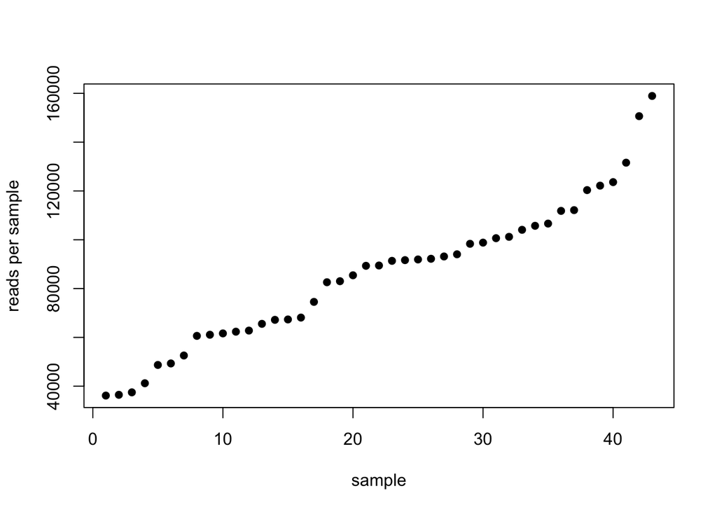

## 1.2) Normalization

Let’s normalize the original dataset by randomly subsampling 36155 reads in each station:

```r
tb16_tax_occur_min36155_t<-t(tb16_tax_occur_min36155)
tb16_tax_occur_ss36155<-rrarefy(tb16_tax_occur_min36155_t, 36155)
```

The normalized table shows the following dimensions and format:

```
## [1]    43 28294
```

```
##                    OTU_1 OTU_2 OTU_3 OTU_4 OTU_5
## TARA_102_SUR_0d2_3     0     0     0     1     0
## TARA_109_SUR_0d2_3     1     0     0     0     0
## TARA_110_SUR_0d2_3     0     0     0     0     0
## TARA_111_SUR_0d2_3     0     0     0     1     0
## TARA_112_SUR_0d2_3     0     0     0     0     0
```

Its content fits with the expected normalization values (36155 reads per station):

```r
rowSums(tb16_tax_occur_ss36155)
```

```
## TARA_102_SUR_0d2_3 TARA_109_SUR_0d2_3 TARA_110_SUR_0d2_3
##              36155              36155              36155
## TARA_111_SUR_0d2_3 TARA_112_SUR_0d2_3 TARA_122_SUR_0d2_3
##              36155              36155              36155
## TARA_123_SUR_0d2_3 TARA_124_SUR_0d2_3 TARA_125_SUR_0d2_3
##              36155              36155              36155
## TARA_128_SUR_0d2_3 TARA_132_SUR_0d2_3 TARA_133_SUR_0d2_3
##              36155              36155              36155
## TARA_137_SUR_0d2_3 TARA_138_SUR_0d2_3 TARA_140_SUR_0d2_3
##              36155              36155              36155
## TARA_142_SUR_0d2_3 TARA_145_SUR_0d2_3 TARA_146_SUR_0d2_3
##              36155              36155              36155
## TARA_148_SUR_0d2_3 TARA_149_SUR_0d2_3 TARA_150_SUR_0d2_3
##              36155              36155              36155
## TARA_151_SUR_0d2_3 TARA_152_SUR_0d2_3  TARA_56_SUR_0d2_3
##              36155              36155              36155
##  TARA_57_SUR_0d2_3  TARA_62_SUR_0d2_3  TARA_64_SUR_0d2_3
##              36155              36155              36155
##  TARA_65_SUR_0d2_3  TARA_66_SUR_0d2_3  TARA_68_SUR_0d2_3
##              36155              36155              36155
##  TARA_72_SUR_0d2_3  TARA_76_SUR_0d2_3  TARA_78_SUR_0d2_3
##              36155              36155              36155
##  TARA_82_SUR_0d2_3  TARA_84_SUR_0d2_3  TARA_85_SUR_0d2_3
##              36155              36155              36155
##  TARA_96_SUR_0d2_3  TARA_98_SUR_0d2_3  TARA_99_SUR_0d2_3
##              36155              36155              36155
##             MP0311             MP1517             MP1672
##              36155              36155              36155
##             MP2821
##              36155
```

Let’s check out how many OTUs don’t appear in the new table:

```r
length(which(colSums(tb16_tax_occur_ss36155)==0)) #46
```

```
## [1] 8531
```

```r
tb16_tax_occur_ss36155_no_cero<-tb16_tax_occur_ss36155[,-(which(colSums(tb16_tax_occur_ss36155)==0))]
tb16_tax_occur_ss36155_no_cero<-tb16_tax_occur_ss36155_no_cero[mixedorder(row.names(tb16_tax_occur_ss36155_no_cero)),]
dim(tb16_tax_occur_ss36155_no_cero) #92 913
```

```
## [1]    43 19763
```

Datasets summary:

```r
dim(tb16_tax) #959 128
```

```
## [1] 28294    58
```

```r
dim(tb16_tax_occur) #959 122
```

```
## [1] 28294    55
```

```r
dim(tb16_tax_occur_ss36155_no_cero) #92 913
```

```
## [1]    43 19763
```